# U.S. NOAA Storm Database Analysis

J. Baker

12/11/2020

**Introduction**

In this project we explore the United States NOAA storm database. The database tracks major storm and weather event characteristics. Characteristics include when and where storms occur as well as estimates of fatalities, injuries, property damage and loss. The analysis below will focus on two questions and evaluate events that cause injury and fatalities and property damage.

**Loading**

*Loading Libraries*

```r
# Loading required libraries
library("ggplot2")
library("gridExtra")
library("R.utils")
```

*Loading and Reading Data*

```r
#Reading dataset
stormData <- read.csv("repdata_data_StormData.csv", sep = ",")
```

**Summary of Data** *Review summary of the data that is available to process.*

```r
summary(stormData)
```

```
##     STATE__       BGN_DATE           BGN_TIME          TIME_ZONE
##  Min.   : 1.0   Length:902297      Length:902297      Length:902297
##  1st Qu.:19.0   Class :character   Class :character   Class :character
##  Median :30.0   Mode  :character   Mode  :character   Mode  :character
##  Mean   :31.2
##  3rd Qu.:45.0
##  Max.   :95.0
##
##      COUNTY       COUNTYNAME           STATE              EVTYPE
##  Min.   :  0.0   Length:902297      Length:902297      Length:902297
##  1st Qu.: 31.0   Class :character   Class :character   Class :character
##  Median : 75.0   Mode  :character   Mode  :character   Mode  :character
##  Mean   :100.6
##  3rd Qu.:131.0
##  Max.   :873.0
##
##    BGN_RANGE          BGN_AZI           BGN_LOCATI          END_DATE
##  Min.   :   0.000   Length:902297      Length:902297      Length:902297
##  1st Qu.:   0.000   Class :character   Class :character   Class :character
##  Median :   0.000   Mode  :character   Mode  :character   Mode  :character
##  Mean   :   1.484
##  3rd Qu.:   1.000
##  Max.   :3749.000
##
##    END_TIME           COUNTY_END COUNTYENDN       END_RANGE
##  Length:902297      Min.   :0    Mode:logical   Min.   :  0.0000
##  Class :character   1st Qu.:0    NA's:902297    1st Qu.:  0.0000
##  Mode  :character   Median :0                   Median :  0.0000
##                     Mean   :0                   Mean   :  0.9862
##                     3rd Qu.:0                   3rd Qu.:  0.0000
##                     Max.   :0                   Max.   :925.0000
##
##    END_AZI           END_LOCATI            LENGTH              WIDTH
##  Length:902297      Length:902297      Min.   :   0.0000   Min.   :   0.000
##  Class :character   Class :character   1st Qu.:   0.0000   1st Qu.:   0.000
##  Mode  :character   Mode  :character   Median :   0.0000   Median :   0.000
##                                        Mean   :   0.2301   Mean   :   7.503
##                                        3rd Qu.:   0.0000   3rd Qu.:   0.000
##                                        Max.   :2315.0000   Max.   :4400.000
##
```

[output cut: 25 more lines]

```
##  Min.   :-14451   Min.   :   0   Min.   :-14455   Length:902297
##  1st Qu.:  7247   1st Qu.:   0   1st Qu.:     0   Class :character
##  Median :  8707   Median :   0   Median :     0   Mode  :character
##  Mean   :  6940   Mean   :1452   Mean   :  3509
##  3rd Qu.:  9605   3rd Qu.:3549   3rd Qu.:  8735
##  Max.   : 17124   Max.   :9706   Max.   :106220
##                   NA's   :40
##      REFNUM
##  Min.   :     1
##  1st Qu.:225575
##  Median :451149
##  Mean   :451149
##  3rd Qu.:676723
##  Max.   :902297
##
```

**Data Processing** *We will process the data in the following ways for both Question 1 and 2 (See #):*

```r
#Trim data set to include required columns
stormEvnt <- stormData[, c("BGN_DATE", "EVTYPE", "FATALITIES", "INJURIES",
                            "PROPDMG", "PROPDMGEXP", "CROPDMG", "CROPDMGEXP")]

#Create a new subset for Q1 & Q2

#Selecting data for Fatalities and Injuries for Q1
eventHlth <- subset(stormEvnt, !stormEvnt$FATALITIES == 0 & !stormEvnt$INJURIES ==
                            0, select = c(EVTYPE, FATALITIES, INJURIES))

#Selecting data for Property Damage and Crop Damage for Q2
eventEcon <- subset(stormEvnt, !stormEvnt$PROPDMG == 0 & !stormEvnt$CROPDMG ==
                            0, select = c(EVTYPE, PROPDMG, PROPDMGEXP, CROPDMG, CROPDMGEXP))
```

**Question 1 - Across the US, which types of events (as indicated in the EVTYPE variable) are most harmful with respect to population health?**

*Data Analysis for Question 1*

*We will process the data in the following ways (See #):*

```r
#For Q1 - Create a separate data set for Injury and Fatalities
eventHlth_Death <- aggregate(eventHlth$FATALITIES, by = list(eventHlth$EVTYPE),
                             FUN = sum)
#Naming columns
colnames(eventHlth_Death) <- c("EVENTTYPE", "FATALITIES")
eventHlth_Inj <- aggregate(eventHlth$INJURIES, by = list(eventHlth$EVTYPE),
                           FUN = sum)
colnames(eventHlth_Inj) <- c("EVENTTYPE", "INJURIES")

#Reorder 2 dataset and filter TOP 5 events for both
eventHlth_Death <- eventHlth_Death[order(eventHlth_Death$FATALITIES, decreasing = TRUE),
][1:5, ]
eventHlth_Inj <- eventHlth_Inj[order(eventHlth_Inj$INJURIES, decreasing = TRUE),
                               ][1:5, ]
```

*Results for Question 1*

*We process data to include the TOP 5 major causes of both fatalities and injuries.*

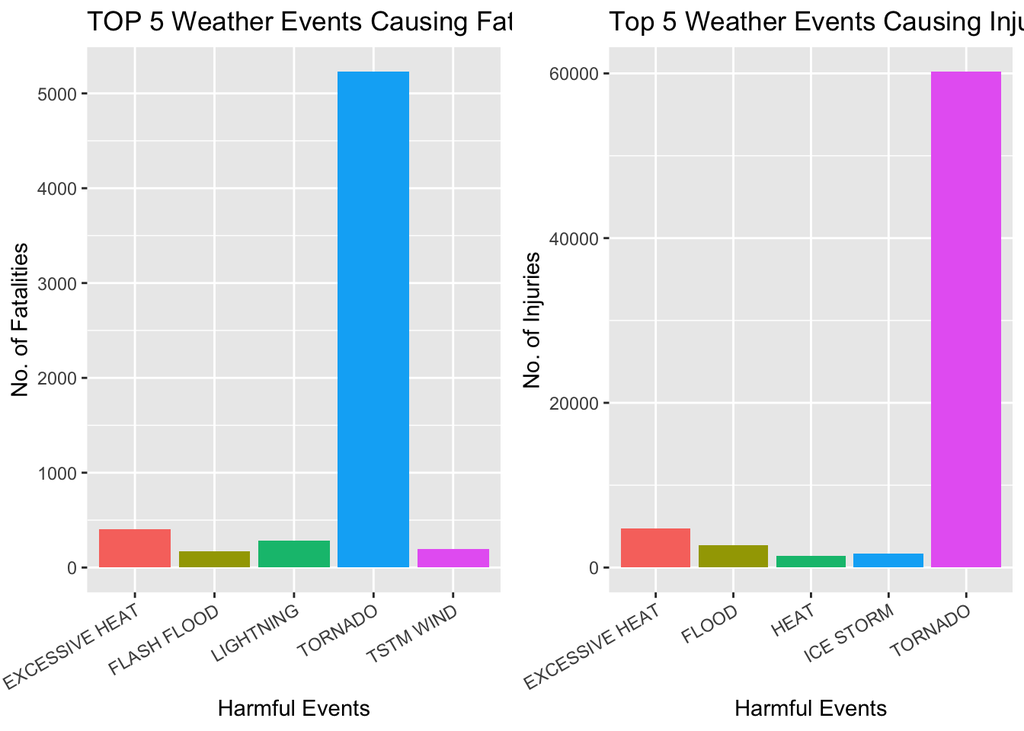

```r
#Fatalities plot stored in: Death_plot
Death_plot <- ggplot() + geom_bar(data = eventHlth_Death, aes(x = EVENTTYPE,
        y = FATALITIES, fill = interaction(FATALITIES, EVENTTYPE)), stat = "identity",
        show.legend = F) + theme(axis.text.x = element_text(angle = 30, hjust = 1)) +
        xlab("Harmful Events") + ylab("No. of Fatalities") + ggtitle ("TOP 5 Weather Events Causing Fatalities") +
        theme(axis.text.x = element_text(angle = 30, hjust = 1))
#Injuries plot stored in: Inj_plot
Inj_plot <- ggplot() + geom_bar(data = eventHlth_Inj, aes(x = EVENTTYPE, y = INJURIES,
        fill = interaction(INJURIES, EVENTTYPE)), stat = "identity", show.legend = F) +
        theme(axis.text.x = element_text(angle = 30, hjust = 1)) + xlab("Harmful Events") +
        ylab("No. of Injuries") + ggtitle("Top 5 Weather Events Causing Injuries") +
        theme(axis.text.x = element_text(angle = 30, hjust = 1))

#Visualized and both plots generated.  Divide space equals two columns
grid.arrange(Death_plot, Inj_plot, ncol = 2)
```

*TORNADOS - The overwhelming cause of both FATALITIES and INJURIES related to weather events.*

**Question 2 - Across the United States, which types of events have the greatest economic consequences?**

*Data Analysis for Question 2* *We will process the data aimed at showing the most harmful events to an economy. (See #):*

```r
#Selecting the entries for Economy
eventEcon <- subset(eventEcon, eventEcon$PROPDMGEXP == "K" | eventEcon$PROPDMGEXP ==
                            "k" | eventEcon$PROPDMGEXP == "M" | eventEcon$PROPDMGEXP == "m" |
                            eventEcon$PROPDMGEXP == "B" | eventEcon$PROPDMGEXP == "b")

eventEcon <- subset(eventEcon, eventEcon$CROPDMGEXP == "K" | eventEcon$CROPDMGEXP ==
                            "k" | eventEcon$CROPDMGEXP == "M" | eventEcon$CROPDMGEXP == "m" |
                            eventEcon$CROPDMGEXP == "B" | eventEcon$CROPDMGEXP == "b")

#Convert econ values to a number
eventEcon$PROPDMGEXP <- gsub("m", 1e+06, eventEcon$PROPDMGEXP, ignore.case = TRUE)

eventEcon$PROPDMGEXP <- gsub("k", 1000, eventEcon$PROPDMGEXP, ignore.case = TRUE)

eventEcon$PROPDMGEXP <- gsub("b", 1e+09, eventEcon$PROPDMGEXP, ignore.case = TRUE)

eventEcon$PROPDMGEXP <- as.numeric(eventEcon$PROPDMGEXP)

eventEcon$CROPDMGEXP <- gsub("m", 1e+06, eventEcon$CROPDMGEXP, ignore.case = TRUE)

eventEcon$CROPDMGEXP <- gsub("k", 1000, eventEcon$CROPDMGEXP, ignore.case = TRUE)

eventEcon$CROPDMGEXP <- gsub("b", 1e+09, eventEcon$CROPDMGEXP, ignore.case = TRUE)

eventEcon$CROPDMGEXP <- as.numeric(eventEcon$CROPDMGEXP)

eventEcon$PROPDMGEXP <- as.numeric(eventEcon$PROPDMGEXP)

#Sum of damage by each event type
eventEcon$TotalDMG <- (eventEcon$CROPDMG * eventEcon$CROPDMGEXP) +
        (eventEcon$PROPDMG * eventEcon$CROPDMGEXP)

eventEcon <- aggregate(eventEcon$TotalDMG, by = list(eventEcon$EVTYPE),
                       FUN = sum)

colnames(eventEcon) <- c("EVTYPE", "TOTALDMG")

#Event type by rank (highest damage cost) using TOP 5 cols
eventEcon <- eventEcon[order(eventEcon$TOTALDMG, decreasing = TRUE),
                       ]
eventEcon <- eventEcon[1:5, ]
```

*Results for Question 2* *We plot the graph to show the output.*

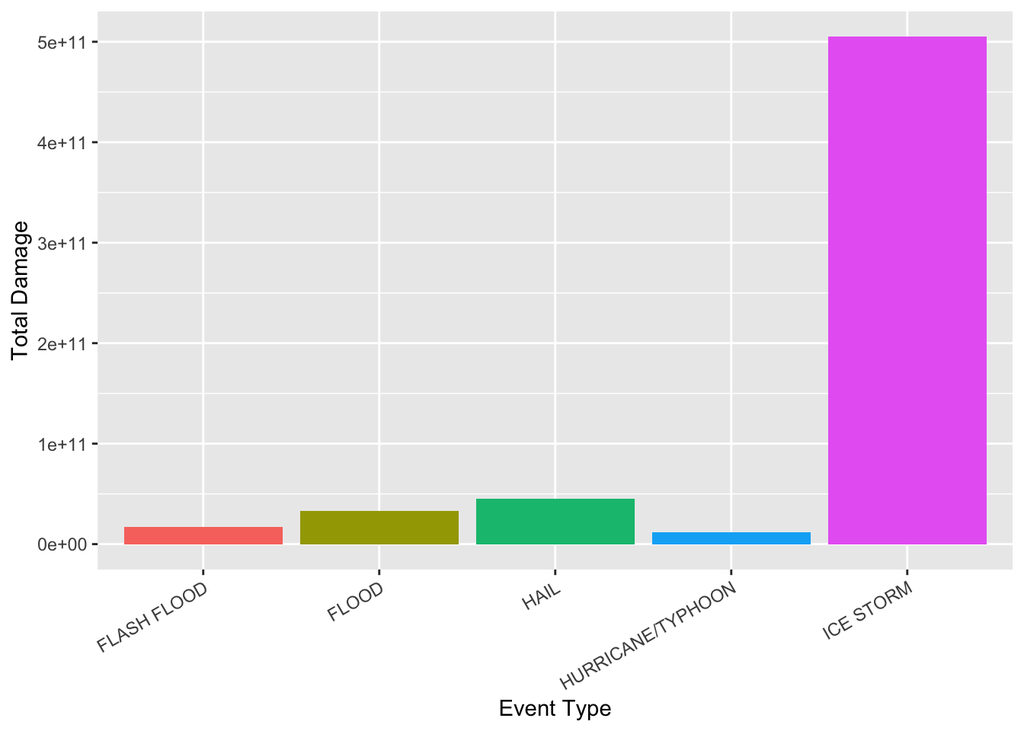

```r
ggplot() + geom_bar(data = eventEcon, aes(x = EVTYPE, y = TOTALDMG, fill = interaction(TOTALDMG, EVTYPE)),
                    stat = "identity", show.legend = F) + theme(axis.text.x = element_text(angle = 30, hjust = 1)) +
                        xlab("Event Type") + ylab("Total Damage")
```